# IODS course project

Lenka Dvorakova

# Introduction to Open Data Science - Course Project

# About the project

The link to my GitHub repository is: https://github.com/tulenovo/IODS-project.

I am really excited about this course, since I have used RStudio in the past to perform some statistical tests for my manuscript, but haven’t constructively learned how to actually use it :) I’ve discovered this course in Yammer, which I usually don’t use that often, so I am pretty lucky!

# Chapter 2: Regression and model validation

In the first part of this exercise I’ve revised the knowledge gained in the DataComp exercise about reading data from the internet or files, working with the data frames and saving the data again. Script is saved in /data/create_learning2014.R.

The second part of the exercise is about data analysis. First, the data from first part of the exercise is loaded:

```r
learning2014 <- read.csv("data/learning2014.csv",header = TRUE,row.names = 1)
# Changing the column gender to structure: factor
learning2014$gender <- as.factor(learning2014$gender)
str(learning2014)
```

```
## 'data.frame':    166 obs. of  7 variables:
##  $ gender  : Factor w/ 2 levels "F","M": 1 2 1 2 2 1 2 1 2 1 ...
##  $ Age     : int  53 55 49 53 49 38 50 37 37 42 ...
##  $ attitude: num  3.7 3.1 2.5 3.5 3.7 3.8 3.5 2.9 3.8 2.1 ...
##  $ deep    : num  3.58 2.92 3.5 3.5 3.67 ...
##  $ stra    : num  3.38 2.75 3.62 3.12 3.62 ...
##  $ surf    : num  2.58 3.17 2.25 2.25 2.83 ...
##  $ Points  : int  25 12 24 10 22 21 21 31 24 26 ...
```

```r
dim(learning2014)
```

```
## [1] 166   7
```

The dataset learning2014 is from the international survey conducted in 2014-2015 from 183 students, who attended an introductory statistical course, 166 of which attended the final exam and therefore are kept in the variable learning2014. Students were asked questions about their attitude towards learning statistics, which were grouped into deep, surface and strategic learning (deep, stra and surf columns respectively). Other columns were: the global attitude towards statistics, age and gender (Attitude, Age and gender respectively). Points obtained in the final exam are listed under Points.

```r
#accessing the needed libraries
library(GGally)
```

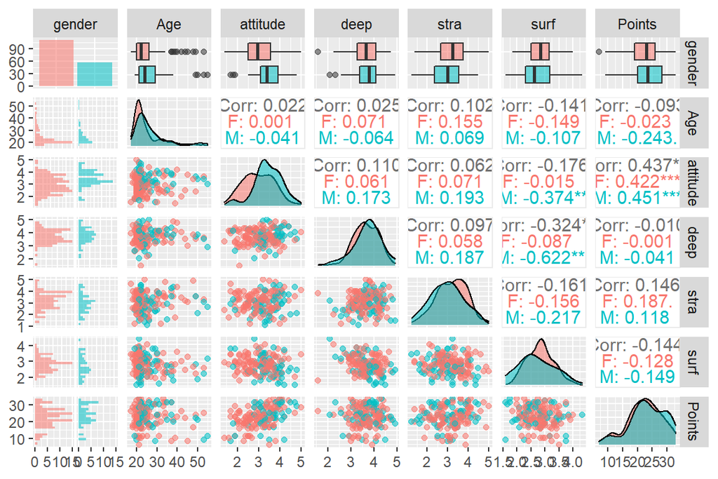

```r
library(ggplot2)

# create a plot matrix with ggpairs() for the learning2014
p <- ggpairs(learning2014, mapping = aes(col=gender,alpha=0.3), lower = list(combo = wrap("facethist", bins = 20)))

# draw the plot
p
```

The scatter plots and correlation are suggesting that the dependent variable Points is related to the variable attitude (based on the correlation value and the distribution of the variables). Distribution of the variable age is very similar in both genders and skewed (which is expected for students at the university).

For the regression model, the variables attitude, stra and surf were picked as explanatory, since their correlation value to the dependent variable Points was the highest from available variables.

```r
#regression model with dependent variable points and attitude, stra and surf as explanatory variables and a summary of the model.
lm_points <- lm(Points ~ attitude + stra + surf, data = learning2014)
summary(lm_points)
```

```
##
## Call:
## lm(formula = Points ~ attitude + stra + surf, data = learning2014)
##
## Residuals:
##      Min       1Q   Median       3Q      Max
## -17.1550  -3.4346   0.5156   3.6401  10.8952
##
## Coefficients:
##             Estimate Std. Error t value Pr(>|t|)
## (Intercept)  11.0171     3.6837   2.991  0.00322 **
## attitude      3.3952     0.5741   5.913 1.93e-08 ***
## stra          0.8531     0.5416   1.575  0.11716
## surf         -0.5861     0.8014  -0.731  0.46563
## ---
## Signif. codes:  0 '***' 0.001 '**' 0.01 '*' 0.05 '.' 0.1 ' ' 1
##
## Residual standard error: 5.296 on 162 degrees of freedom
## Multiple R-squared:  0.2074, Adjusted R-squared:  0.1927
## F-statistic: 14.13 on 3 and 162 DF,  p-value: 3.156e-08
```

All explanatory variables accounted for 19% of variability (based on R<sup>2</sup>) and since the p-value of the F-test is very low, so there is evidence that at least one regression coefficient is not a zero. Based on the t-value, there is strong evidence that only the regression coefficient of the variable attitude is non-zero.

Now the regression model only with only attitude as a explanatory variable was run.

```r
#regression model with dependent variable points and attitude as explanatory variable and a summary of the model.
lm_points_att <- lm(Points ~ attitude, data = learning2014)
summary(lm_points_att)
```

```
##
## Call:
## lm(formula = Points ~ attitude, data = learning2014)
##
## Residuals:
##      Min       1Q   Median       3Q      Max
## -16.9763  -3.2119   0.4339   4.1534  10.6645
##
## Coefficients:
##             Estimate Std. Error t value Pr(>|t|)
## (Intercept)  11.6372     1.8303   6.358 1.95e-09 ***
## attitude      3.5255     0.5674   6.214 4.12e-09 ***
## ---
## Signif. codes:  0 '***' 0.001 '**' 0.01 '*' 0.05 '.' 0.1 ' ' 1
##
## Residual standard error: 5.32 on 164 degrees of freedom
## Multiple R-squared:  0.1906, Adjusted R-squared:  0.1856
## F-statistic: 38.61 on 1 and 164 DF,  p-value: 4.119e-09
```

As we can see from the summary of the model lm_points_att, there is not much difference between running the model with or without the additional variables.

The graphical validation of the model lm_points:

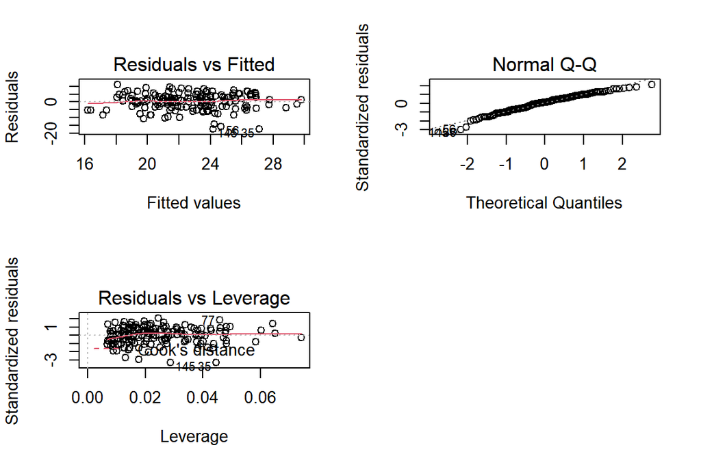

```r
#plotting the Residuals vs Fitted values, Normal QQ-plot and Residuals vs Leverage
par(mfrow = c(2,2))
plot(lm_points,which = c(1,2,5))
```

# Chapter 3: Logistic regression

Loading data from the url:

```r
library(dplyr)
url <- "https://github.com/rsund/IODS-project/raw/master/data/alc.csv"


# read the csv table
alc <- read.table(url, sep = "," , header=TRUE)
glimpse(alc)
```

```
## Rows: 370
## Columns: 51
## $ school     <chr> "GP", "GP", "GP", "GP", "GP", "GP", "GP", "GP", "GP", "GP",~
## $ sex        <chr> "F", "F", "F", "F", "F", "F", "F", "F", "F", "F", "F", "F",~
## $ age        <int> 15, 15, 15, 15, 15, 15, 15, 15, 15, 15, 15, 15, 15, 15, 15,~
## $ address    <chr> "R", "R", "R", "R", "R", "R", "R", "R", "R", "U", "U", "U",~
## $ famsize    <chr> "GT3", "GT3", "GT3", "GT3", "GT3", "GT3", "GT3", "LE3", "LE~
## $ Pstatus    <chr> "T", "T", "T", "T", "T", "T", "T", "T", "T", "A", "A", "T",~
## $ Medu       <int> 1, 1, 2, 2, 3, 3, 3, 2, 3, 3, 4, 1, 1, 1, 1, 1, 2, 2, 2, 3,~
## $ Fedu       <int> 1, 1, 2, 4, 3, 4, 4, 2, 1, 3, 3, 1, 1, 1, 2, 2, 1, 2, 3, 2,~
## $ Mjob       <chr> "at_home", "other", "at_home", "services", "services", "ser~
## $ Fjob       <chr> "other", "other", "other", "health", "services", "health", ~
## $ reason     <chr> "home", "reputation", "reputation", "course", "reputation",~
## $ guardian   <chr> "mother", "mother", "mother", "mother", "other", "mother", ~
## $ traveltime <int> 2, 1, 1, 1, 2, 1, 2, 2, 2, 1, 1, 3, 1, 1, 1, 1, 3, 1, 2, 1,~
```

[output cut: 38 more lines]

This dataset is providing information from two Portugese schools regarding the students performance in Mathematics (mat) and Protugese language (por). G1 G2 and G3 are the grades in first, second period and the final grade respectively. The dataset inlcudes also information about the student background like the parents job, alcohol consuption, extra-curricular activities and others. More information is found here: https://archive.ics.uci.edu/ml/datasets/Student+Performance.

[figure not shown]

```r
library(ggplot2)

# initialize a plot of high_use and G3
g1 <- ggplot(alc, aes(x = high_use, y = G3))

# define the plot as a boxplot and draw it
g1 + geom_boxplot() + ylab("grade") + ggtitle("Student absences by alcohol consumption")
```

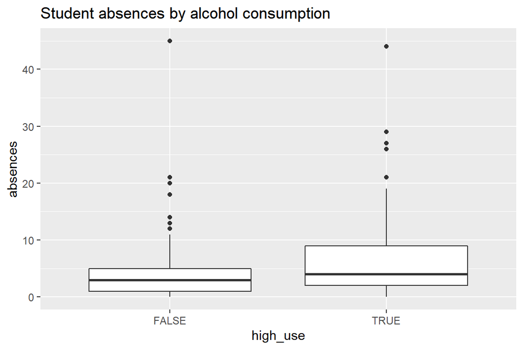

```r
# initialise a plot of high_use and absences
g2 <- ggplot(alc, aes(x = high_use, y = absences))

# define the plot as a boxplot and draw it
g2 + geom_boxplot() + ggtitle("Student absences by alcohol consumption")
```

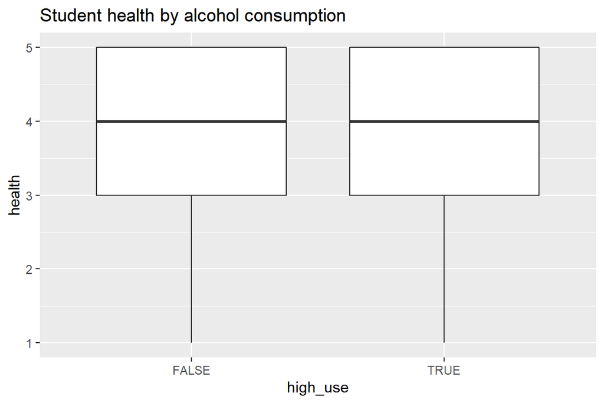

```r
# initialise a plot of high_use and health
g3 <- ggplot(alc, aes(x = high_use, y = health))

# define the plot as a boxplot and draw it
g3 + geom_boxplot() + ggtitle("Student health by alcohol consumption")
```

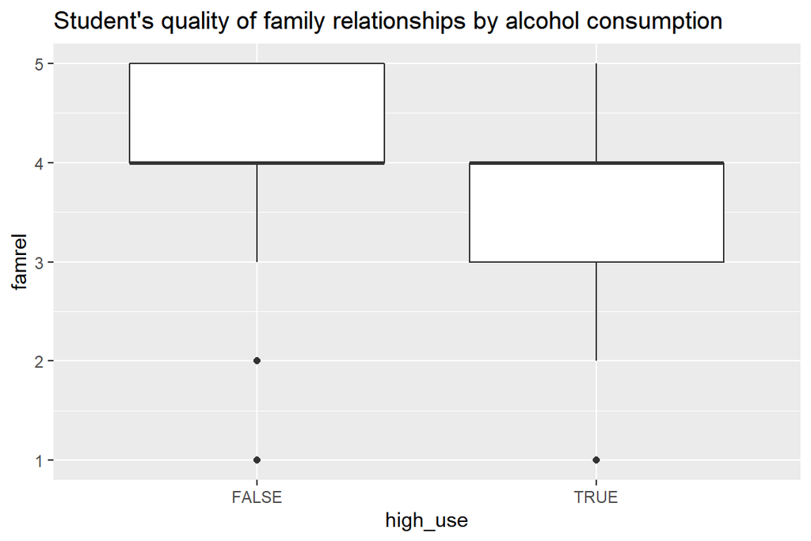

```r
# initialise a plot of high_use and quality of family relationships
g3 <- ggplot(alc, aes(x = high_use, y = famrel))

# define the plot as a boxplot and draw it
g3 + geom_boxplot() + ggtitle("Student's quality of family relationships by alcohol consumption")
```

From the boxplots it seems that the alcohol consumption could be in a relationship with the final grade (G3), where the lower alcohol consumption could lead to better grade. Also, the high alcohol consumption could lead to more absences and students with lower alcohol consumption also seem to have a better quality of family relationships. There seems to be no relationship between the student’s health and the alcohol consumption.

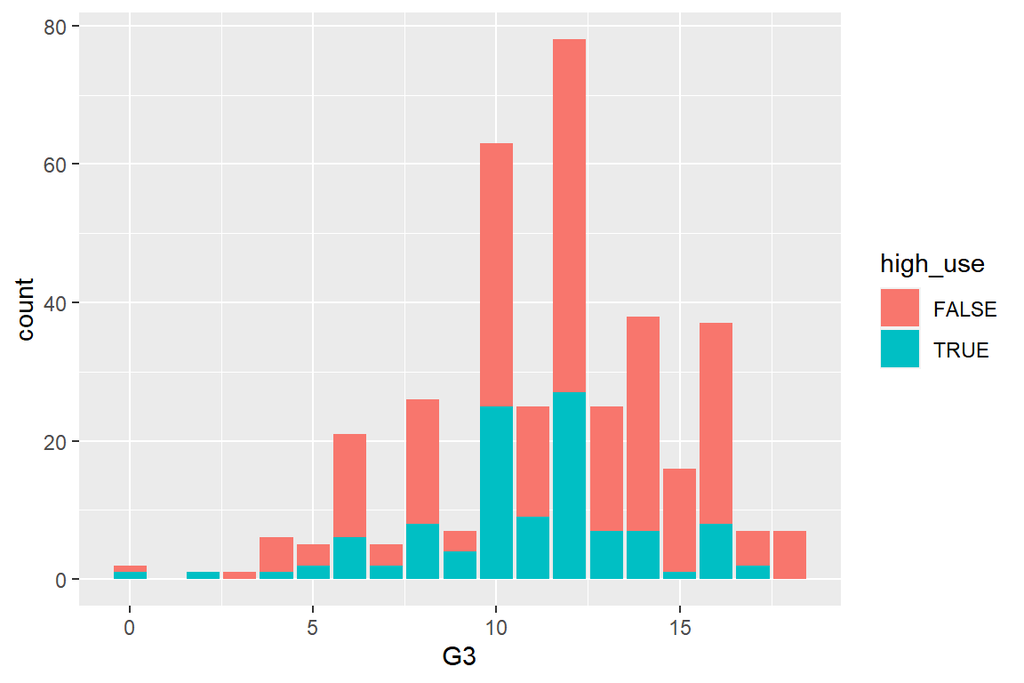

```r
#box plot for the grade by alcohol use
g1 <- ggplot(data = alc, aes(x = G3,fill = high_use))


g1 + geom_bar()
```

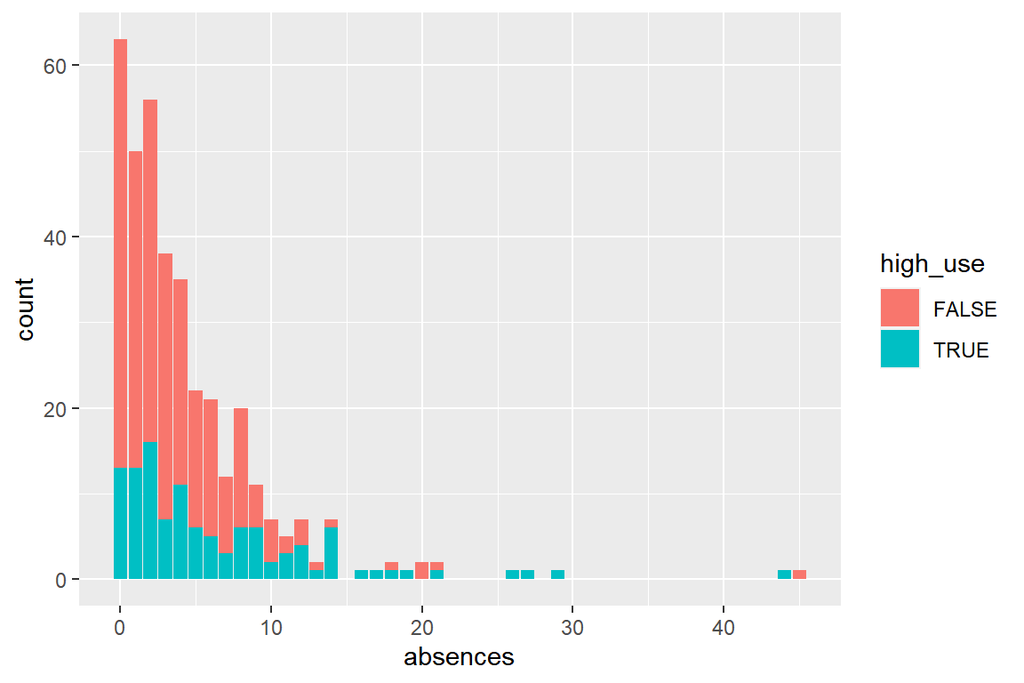

```r
g2 <- ggplot(data = alc, aes(x = absences,fill = high_use))

# define the plot as a bar plot and draw it
g2 + geom_bar()
```

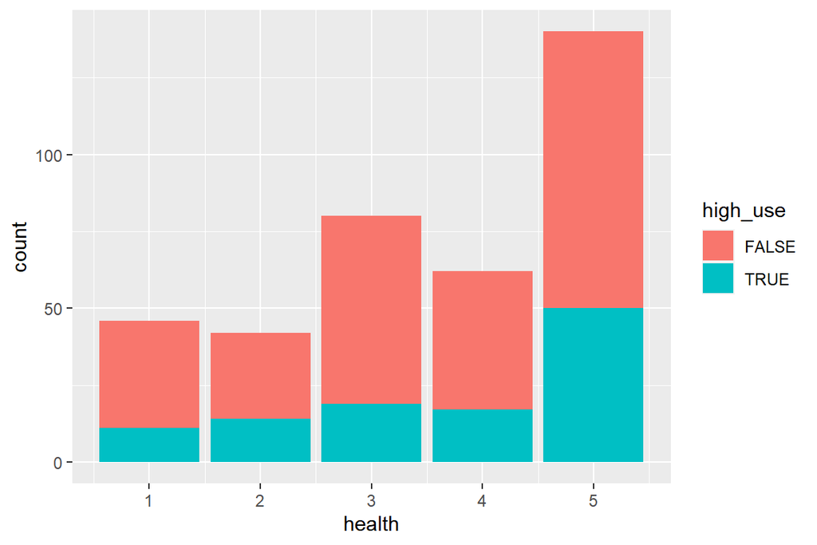

```r
g3 <- ggplot(data = alc, aes(x = health,fill = high_use))

# define the plot as a bar plot and draw it
g3 + geom_bar()
```

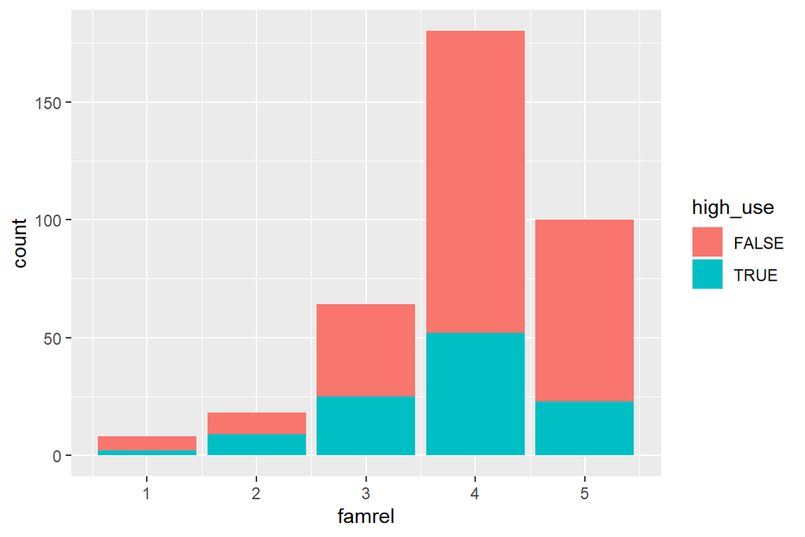

```r
g4 <- ggplot(data = alc, aes(x = famrel,fill = high_use))

# define the plot as a bar plot and draw it
g4 + geom_bar()
```

The logistic model, where the high_use is the target variable and final grade G3, absences, health and quality of family relationships (famrel) are the predictors.

```r
# find the model with glm()
m <- glm(high_use ~ G3 + absences+health+famrel, data = alc, family = "binomial")

# print out a summary of the model
summary(m)
```

```
##
## Call:
## glm(formula = high_use ~ G3 + absences + health + famrel, family = "binomial",
##     data = alc)
##
## Deviance Residuals:
##     Min       1Q   Median       3Q      Max
## -2.3498  -0.8206  -0.6820   1.1424   1.9666
##
## Coefficients:
##             Estimate Std. Error z value Pr(>|z|)
## (Intercept)  0.12490    0.72091   0.173 0.862450
## G3          -0.06840    0.03615  -1.892 0.058439 .
## absences     0.08193    0.02269   3.612 0.000304 ***
## health       0.13687    0.08806   1.554 0.120138
## famrel      -0.27919    0.12753  -2.189 0.028582 *
## ---
## Signif. codes:  0 '***' 0.001 '**' 0.01 '*' 0.05 '.' 0.1 ' ' 1
##
## (Dispersion parameter for binomial family taken to be 1)
##
##     Null deviance: 452.04  on 369  degrees of freedom
## Residual deviance: 423.36  on 365  degrees of freedom
## AIC: 433.36
##
## Number of Fisher Scoring iterations: 4
```

```r
# print out the coefficients of the model
coef(m)
```

```
## (Intercept)          G3    absences      health      famrel
##  0.12490199 -0.06840295  0.08193324  0.13686832 -0.27918935
```

```r
# compute odds ratios (OR)
OR <- coef(m) %>% exp

# compute confidence intervals (CI)
CI <- confint(m) %>% exp
# print out the odds ratios with their confidence intervals
cbind(OR, CI)
```

```
##                    OR     2.5 %    97.5 %
## (Intercept) 1.1330374 0.2735992 4.6635214
## G3          0.9338841 0.8695698 1.0024141
## absences    1.0853833 1.0402838 1.1373505
## health      1.1466771 0.9669919 1.3668428
## famrel      0.7563967 0.5879500 0.9711348
```

```r
# define a loss function (average prediction error)
loss_func <- function(class, prob) {
  n_wrong <- abs(class - prob) > 0.5
  mean(n_wrong)
}

# compute the average number of wrong predictions in the (training) data


# K-fold cross-validation
library(boot)
cv <- cv.glm(data = alc, cost = loss_func, glmfit = m, K = nrow(alc))
cv$delta[1]
```

```
## [1] 0.2918919
```

```r
# average number of wrong predictions in the 10-fold cross validation

cv <- cv.glm(data = alc, cost = loss_func, glmfit = m, K = 10)
# average number of wrong predictions in the 10-fold cross validation
cv$delta[1]
```

```
## [1] 0.2972973
```

# Chapter 4: Clustering and classification

Loading data:

```r
# access the MASS package
library(MASS)
# load the data
data("Boston")
```

Let’s explore the data

```r
library(Hmisc)
library(dbplyr)
library(tidyverse)
```

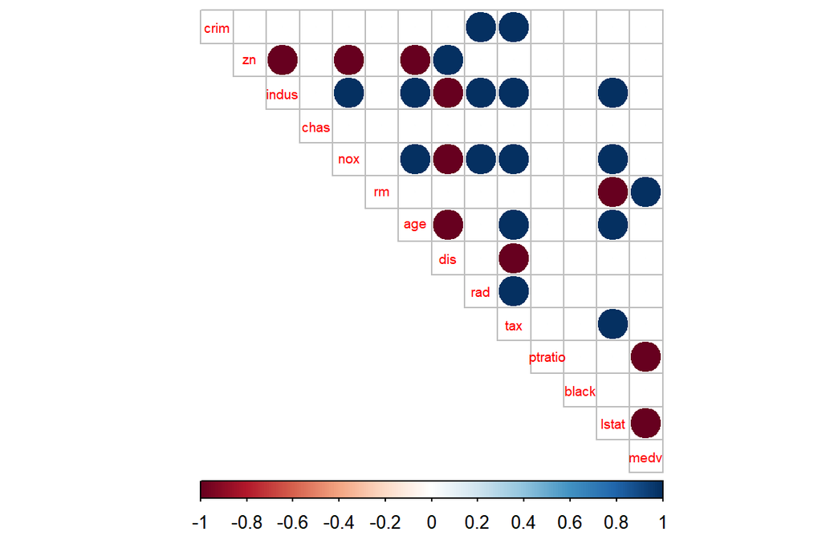

```r
library(ggplot2)
library(corrplot)
# calculate the correlation matrix and round it
cor_matrix<-cor(Boston) %>% round()

# print the correlation matrix


# visualize the correlation matrix
corrplot(cor_matrix, method="circle",type = "upper",cl.pos = "b",tl.pos = "d", tl.cex = 0.6)
```

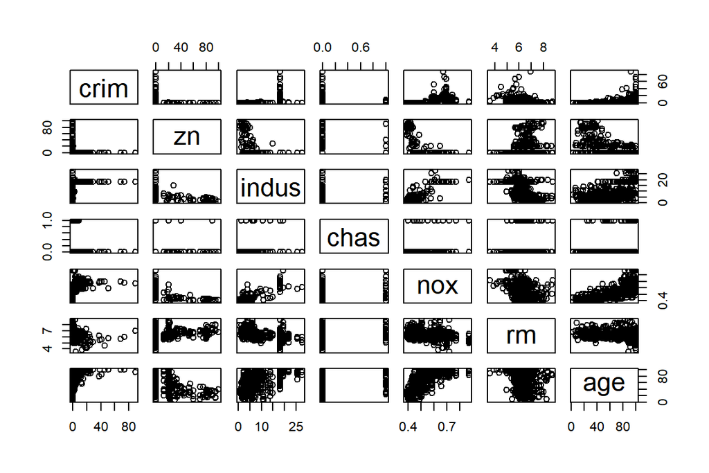

```r
pairs(Boston[1:7])
```

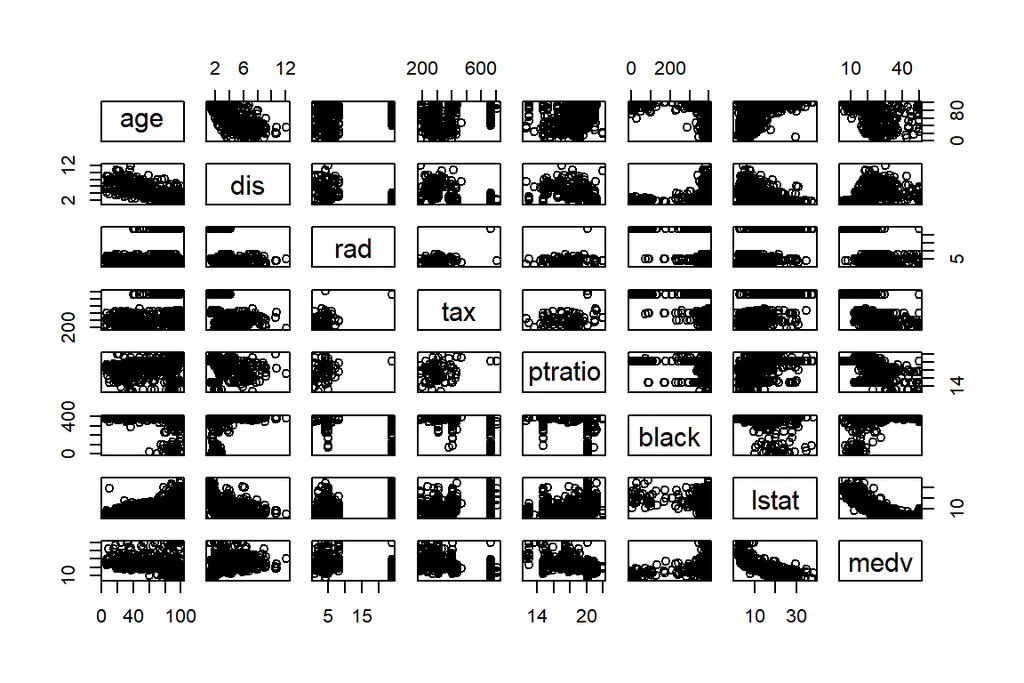

```r
pairs(Boston[7:14])
```

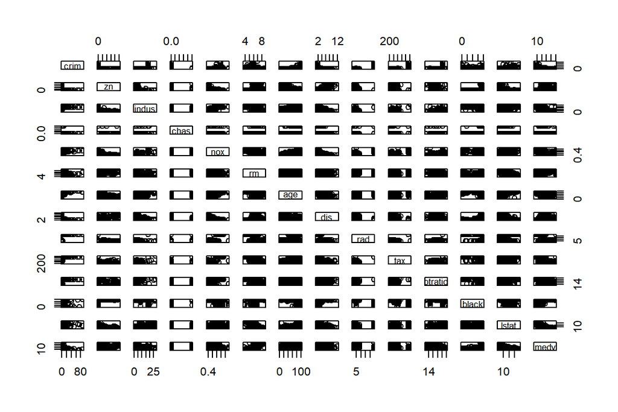

```r
pairs(Boston)
```

```r
#hist.data.frame(Boston)
summary(Boston)
```

```
##       crim                zn             indus            chas
##  Min.   : 0.00632   Min.   :  0.00   Min.   : 0.46   Min.   :0.00000
##  1st Qu.: 0.08205   1st Qu.:  0.00   1st Qu.: 5.19   1st Qu.:0.00000
##  Median : 0.25651   Median :  0.00   Median : 9.69   Median :0.00000
##  Mean   : 3.61352   Mean   : 11.36   Mean   :11.14   Mean   :0.06917
##  3rd Qu.: 3.67708   3rd Qu.: 12.50   3rd Qu.:18.10   3rd Qu.:0.00000
##  Max.   :88.97620   Max.   :100.00   Max.   :27.74   Max.   :1.00000
##       nox               rm             age              dis
##  Min.   :0.3850   Min.   :3.561   Min.   :  2.90   Min.   : 1.130
##  1st Qu.:0.4490   1st Qu.:5.886   1st Qu.: 45.02   1st Qu.: 2.100
##  Median :0.5380   Median :6.208   Median : 77.50   Median : 3.207
##  Mean   :0.5547   Mean   :6.285   Mean   : 68.57   Mean   : 3.795
##  3rd Qu.:0.6240   3rd Qu.:6.623   3rd Qu.: 94.08   3rd Qu.: 5.188
##  Max.   :0.8710   Max.   :8.780   Max.   :100.00   Max.   :12.127
##       rad              tax           ptratio          black
##  Min.   : 1.000   Min.   :187.0   Min.   :12.60   Min.   :  0.32
##  1st Qu.: 4.000   1st Qu.:279.0   1st Qu.:17.40   1st Qu.:375.38
##  Median : 5.000   Median :330.0   Median :19.05   Median :391.44
##  Mean   : 9.549   Mean   :408.2   Mean   :18.46   Mean   :356.67
##  3rd Qu.:24.000   3rd Qu.:666.0   3rd Qu.:20.20   3rd Qu.:396.23
##  Max.   :24.000   Max.   :711.0   Max.   :22.00   Max.   :396.90
##      lstat            medv
##  Min.   : 1.73   Min.   : 5.00
##  1st Qu.: 6.95   1st Qu.:17.02
##  Median :11.36   Median :21.20
##  Mean   :12.65   Mean   :22.53
##  3rd Qu.:16.95   3rd Qu.:25.00
##  Max.   :37.97   Max.   :50.00
```

From the correlation plot we see, that the dummy variable (chas) and does not have any apparent connection to any other variable. Also, the variable explaning the proportions of blacks (black) seems to be not in any connection with other variable. From the matrix plot, there is an interesting relationship between the lower status of the population (lstat) and median value of owner-occupied homes (medv), which seems to be logarithimc, or exponential. In some variables we can see, that there is some clear clustering in two groups (rad and tax vs most of the other variables)

```r
# center and standardize variables
boston_scaled <- scale(Boston)

# summaries of the scaled variables
summary(boston_scaled)
```

```
##       crim                 zn               indus              chas
##  Min.   :-0.419367   Min.   :-0.48724   Min.   :-1.5563   Min.   :-0.2723
##  1st Qu.:-0.410563   1st Qu.:-0.48724   1st Qu.:-0.8668   1st Qu.:-0.2723
##  Median :-0.390280   Median :-0.48724   Median :-0.2109   Median :-0.2723
##  Mean   : 0.000000   Mean   : 0.00000   Mean   : 0.0000   Mean   : 0.0000
##  3rd Qu.: 0.007389   3rd Qu.: 0.04872   3rd Qu.: 1.0150   3rd Qu.:-0.2723
##  Max.   : 9.924110   Max.   : 3.80047   Max.   : 2.4202   Max.   : 3.6648
##       nox                rm               age               dis
##  Min.   :-1.4644   Min.   :-3.8764   Min.   :-2.3331   Min.   :-1.2658
##  1st Qu.:-0.9121   1st Qu.:-0.5681   1st Qu.:-0.8366   1st Qu.:-0.8049
##  Median :-0.1441   Median :-0.1084   Median : 0.3171   Median :-0.2790
##  Mean   : 0.0000   Mean   : 0.0000   Mean   : 0.0000   Mean   : 0.0000
##  3rd Qu.: 0.5981   3rd Qu.: 0.4823   3rd Qu.: 0.9059   3rd Qu.: 0.6617
##  Max.   : 2.7296   Max.   : 3.5515   Max.   : 1.1164   Max.   : 3.9566
##       rad               tax             ptratio            black
##  Min.   :-0.9819   Min.   :-1.3127   Min.   :-2.7047   Min.   :-3.9033
##  1st Qu.:-0.6373   1st Qu.:-0.7668   1st Qu.:-0.4876   1st Qu.: 0.2049
##  Median :-0.5225   Median :-0.4642   Median : 0.2746   Median : 0.3808
##  Mean   : 0.0000   Mean   : 0.0000   Mean   : 0.0000   Mean   : 0.0000
##  3rd Qu.: 1.6596   3rd Qu.: 1.5294   3rd Qu.: 0.8058   3rd Qu.: 0.4332
##  Max.   : 1.6596   Max.   : 1.7964   Max.   : 1.6372   Max.   : 0.4406
##      lstat              medv
##  Min.   :-1.5296   Min.   :-1.9063
##  1st Qu.:-0.7986   1st Qu.:-0.5989
##  Median :-0.1811   Median :-0.1449
##  Mean   : 0.0000   Mean   : 0.0000
##  3rd Qu.: 0.6024   3rd Qu.: 0.2683
##  Max.   : 3.5453   Max.   : 2.9865
```

```r
# change the object to data frame
boston_scaled <- as.data.frame(boston_scaled)

# create a quantile vector of crim and print it
bins <- quantile(boston_scaled$crim)
bins
```

```
##           0%          25%          50%          75%         100%
## -0.419366929 -0.410563278 -0.390280295  0.007389247  9.924109610
```

```r
# create a categorical variable 'crime'
crime <- cut(boston_scaled$crim, breaks = bins, include.lowest = TRUE, labels = c("low","med_low","med_high","high"))

# remove original crim from the dataset
boston_scaled <- dplyr::select(boston_scaled, -crim)

# add the new categorical value to scaled data
boston_scaled <- data.frame(boston_scaled, crime)
# number of rows in the Boston dataset
n <- nrow(boston_scaled)

# choose randomly 80% of the rows
ind <- sample(n,  size = n * 0.8)

# create train set
train <- boston_scaled[ind,]

# create test set
test <- boston_scaled[-ind,]

# save the correct classes from test data
correct_classes <- test$crime

# remove the crime variable from test data
test <- dplyr::select(test, -crime)
```

We have scaled our variables in the Boston dataset and we have created two new variables: train and test, in train there is 80% of the dataset. Next, we will perform the linear discriminant analysis on the train set.

```r
# linear discriminant analysis
lda.fit <- lda(crime ~ ., data = train)

# print the lda.fit object
lda.fit
```

```
## Call:
## lda(crime ~ ., data = train)
##
## Prior probabilities of groups:
##       low   med_low  med_high      high
## 0.2623762 0.2475248 0.2475248 0.2425743
##
## Group means:
##                   zn      indus        chas        nox         rm        age
## low       0.97078470 -0.8908977 -0.08661679 -0.8818486  0.4682192 -0.8709892
## med_low  -0.06811618 -0.3273707 -0.07547406 -0.5823042 -0.1149479 -0.3472930
## med_high -0.38261997  0.2575117  0.12138096  0.4942707  0.1094702  0.4844991
## high     -0.48724019  1.0171960 -0.03128211  1.0767762 -0.4291705  0.8749619
##                 dis        rad        tax     ptratio       black       lstat
## low       0.8596005 -0.6936710 -0.7317205 -0.45400315  0.37778610 -0.77767718
## med_low   0.3850327 -0.5511961 -0.4851581 -0.04043224  0.31721465 -0.15260522
## med_high -0.4198720 -0.3915592 -0.2612312 -0.27923733  0.07519008  0.09882799
## high     -0.8755124  1.6373367  1.5134896  0.77985517 -0.76484342  0.89015206
##                medv
## low       0.5636747
## med_low   0.0216583
## med_high  0.1423485
## high     -0.6853477
##
## Coefficients of linear discriminants:
##                 LD1          LD2         LD3
## zn       0.10683485  0.597925197 -1.00438811
## indus    0.01853637 -0.271219959  0.21022588
## chas    -0.06511138 -0.003838766  0.09552046
## nox      0.38105260 -0.811296143 -1.19455914
## rm      -0.03609868 -0.149779807 -0.21828663
## age      0.34676858 -0.398991718 -0.05850706
## dis     -0.06408050 -0.389244251  0.24414515
## rad      2.99974261  1.090772180 -0.17499282
## tax     -0.01566691 -0.134570499  0.58925341
## ptratio  0.11664952 -0.006974500 -0.23660350
## black   -0.12614574 -0.020025678  0.06709775
## lstat    0.25246333 -0.302637722  0.29207034
## medv     0.18701780 -0.456956756 -0.12282347
##
## Proportion of trace:
##   LD1   LD2   LD3
## 0.943 0.044 0.013
```

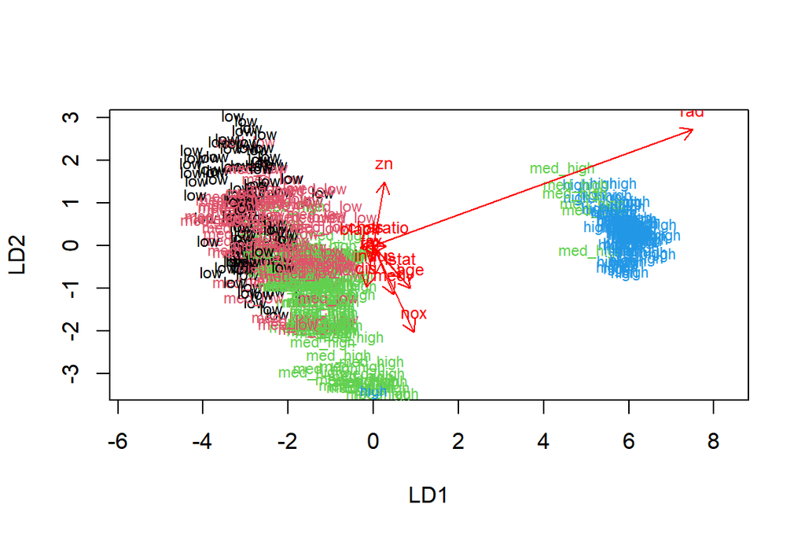

```r
# the function for lda biplot arrows
lda.arrows <- function(x, myscale = 1, arrow_heads = 0.1, color = "red", tex = 0.75, choices = c(1,2)){
  heads <- coef(x)
  arrows(x0 = 0, y0 = 0,
         x1 = myscale * heads[,choices[1]],
         y1 = myscale * heads[,choices[2]], col=color, length = arrow_heads)
  text(myscale * heads[,choices], labels = row.names(heads),
       cex = tex, col=color, pos=3)
}

# target classes as numeric
classes <- as.numeric(train$crime)

# plot the lda results
plot(lda.fit, dimen = 2,col = classes, pch = classes)
lda.arrows(lda.fit, myscale = 2.5)
```

```r
# predict classes with test data
lda.pred <- predict(lda.fit, newdata = test)

# cross tabulate the results
table(correct = correct_classes, predicted = lda.pred$class)
```

```
##           predicted
## correct    low med_low med_high high
##   low       14       7        0    0
##   med_low    4      18        4    0
##   med_high   2      14       10    0
##   high       0       0        0   29
```

```r
# re-loading the data
data("Boston")

# center and standardize variables
boston_scaled <- scale(Boston)

# change the object to data frame
boston_scaled <- as.data.frame(boston_scaled)
# euclidean distance matrix
dist_eu <- dist(Boston)

# look at the summary of the distances
summary(dist_eu)
```

```
##    Min. 1st Qu.  Median    Mean 3rd Qu.    Max.
##   1.119  85.624 170.539 226.315 371.950 626.047
```

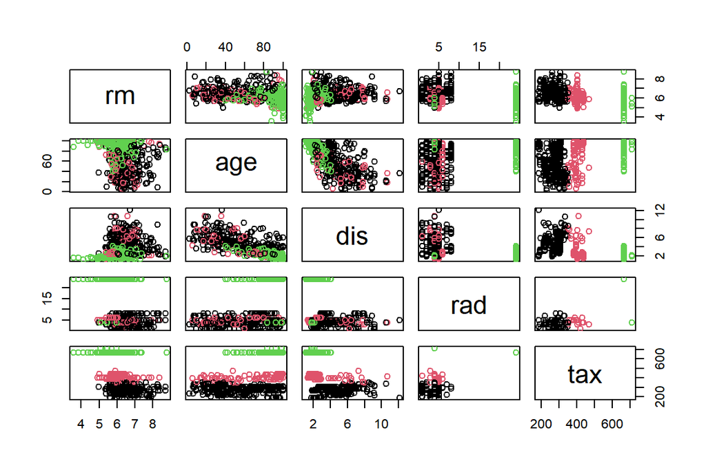

```r
# k-means clustering
km <-kmeans(Boston, centers = 3)

# plot the Boston dataset with clusters
pairs(Boston[6:10], col = km$cluster)
```

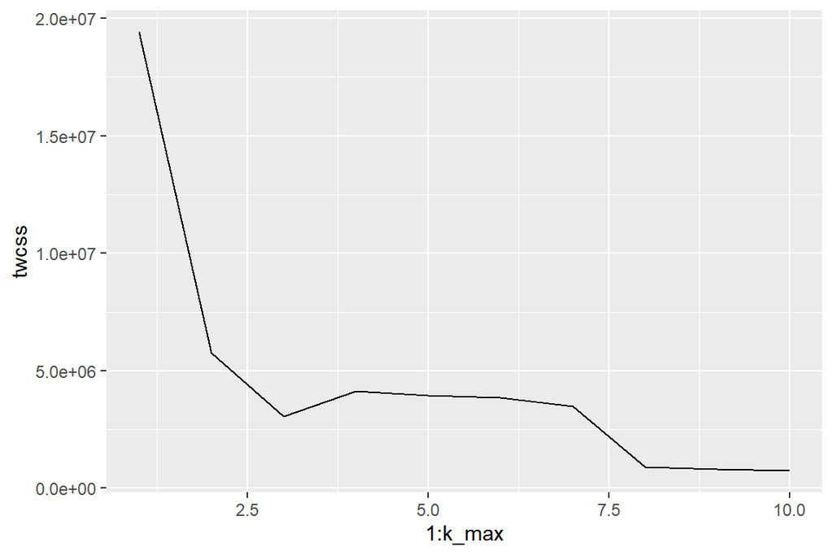

```r
set.seed(123)

# determine the number of clusters
k_max <- 10

# calculate the total within sum of squares
twcss <- sapply(1:k_max, function(k){kmeans(Boston, k)$tot.withinss})

# visualize the results
qplot(x = 1:k_max, y = twcss, geom = 'line')
```

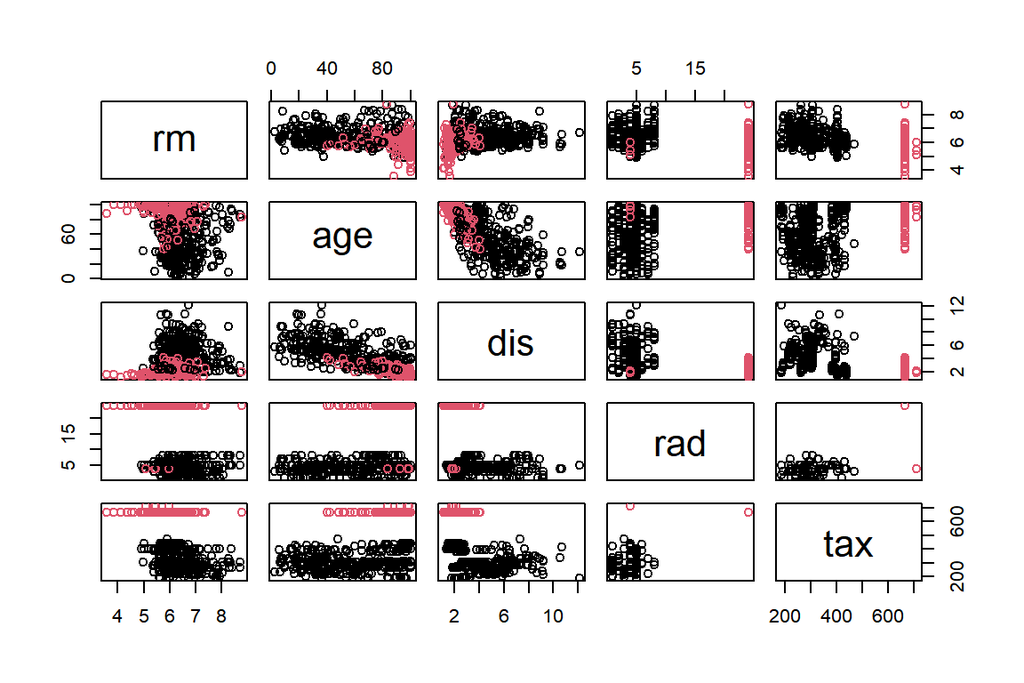

```r
# k-means clustering
km <-kmeans(Boston, centers = 2)

# plot the Boston dataset with clusters
pairs(Boston[6:10], col = km$cluster)
```